# EDA-Lucky 7 (1)

```python
import numpy as np
import pandas as pd
import matplotlib.pyplot as plt
import seaborn as sns
```

```python
from matplotlib import rcParams
rcParams['figure.figsize'] = 12, 4
rcParams['lines.linewidth'] = 3
rcParams['xtick.labelsize'] = 'x-large'
rcParams['ytick.labelsize'] = 'x-large'
```

```python
df = pd.read_csv('hotel_booking_1.csv')
df.info()
```

```
<class 'pandas.core.frame.DataFrame'>
RangeIndex: 119390 entries, 0 to 119389
Data columns (total 36 columns):
 #   Column                          Non-Null Count   Dtype
---  ------                          --------------   -----
 0   hotel                           119390 non-null  object
 1   is_canceled                     119390 non-null  int64
 2   lead_time                       119390 non-null  int64
 3   arrival_date_year               119390 non-null  int64
 4   arrival_date_month              119390 non-null  object
 5   arrival_date_week_number        119390 non-null  int64
 6   arrival_date_day_of_month       119390 non-null  int64
 7   stays_in_weekend_nights         119390 non-null  int64
 8   stays_in_week_nights            119390 non-null  int64
 9   adults                          119390 non-null  int64
```

[output cut: 28 more lines]

```python
df.describe()
```

|  | is_canceled | lead_time | arrival_date_year | arrival_date_week_number | arrival_date_day_of_month | stays_in_weekend_nights | stays_in_week_nights | adults | children | babies | is_repeated_guest | previous_cancellations | previous_bookings_not_canceled | booking_changes | agent | company | days_in_waiting_list | adr | required_car_parking_spaces | total_of_special_requests |
| --- | --- | --- | --- | --- | --- | --- | --- | --- | --- | --- | --- | --- | --- | --- | --- | --- | --- | --- | --- | --- |
| count | 119390.000000 | 119390.000000 | 119390.000000 | 119390.000000 | 119390.000000 | 119390.000000 | 119390.000000 | 119390.000000 | 119386.000000 | 119390.000000 | 119390.000000 | 119390.000000 | 119390.000000 | 119390.000000 | 103050.000000 | 6797.000000 | 119390.000000 | 119390.000000 | 119390.000000 | 119390.000000 |
| mean | 0.370416 | 104.011416 | 2016.156554 | 27.165173 | 15.798241 | 0.927599 | 2.500302 | 1.856403 | 0.103890 | 0.007949 | 0.031912 | 0.087118 | 0.137097 | 0.221124 | 86.693382 | 189.266735 | 2.321149 | 101.831122 | 0.062518 | 0.571363 |
| std | 0.482918 | 106.863097 | 0.707476 | 13.605138 | 8.780829 | 0.998613 | 1.908286 | 0.579261 | 0.398561 | 0.097436 | 0.175767 | 0.844336 | 1.497437 | 0.652306 | 110.774548 | 131.655015 | 17.594721 | 50.535790 | 0.245291 | 0.792798 |
| min | 0.000000 | 0.000000 | 2015.000000 | 1.000000 | 1.000000 | 0.000000 | 0.000000 | 0.000000 | 0.000000 | 0.000000 | 0.000000 | 0.000000 | 0.000000 | 0.000000 | 1.000000 | 6.000000 | 0.000000 | -6.380000 | 0.000000 | 0.000000 |
| 25% | 0.000000 | 18.000000 | 2016.000000 | 16.000000 | 8.000000 | 0.000000 | 1.000000 | 2.000000 | 0.000000 | 0.000000 | 0.000000 | 0.000000 | 0.000000 | 0.000000 | 9.000000 | 62.000000 | 0.000000 | 69.290000 | 0.000000 | 0.000000 |
| 50% | 0.000000 | 69.000000 | 2016.000000 | 28.000000 | 16.000000 | 1.000000 | 2.000000 | 2.000000 | 0.000000 | 0.000000 | 0.000000 | 0.000000 | 0.000000 | 0.000000 | 14.000000 | 179.000000 | 0.000000 | 94.575000 | 0.000000 | 0.000000 |
| 75% | 1.000000 | 160.000000 | 2017.000000 | 38.000000 | 23.000000 | 2.000000 | 3.000000 | 2.000000 | 0.000000 | 0.000000 | 0.000000 | 0.000000 | 0.000000 | 0.000000 | 229.000000 | 270.000000 | 0.000000 | 126.000000 | 0.000000 | 1.000000 |
| max | 1.000000 | 737.000000 | 2017.000000 | 53.000000 | 31.000000 | 19.000000 | 50.000000 | 55.000000 | 10.000000 | 10.000000 | 1.000000 | 26.000000 | 72.000000 | 21.000000 | 535.000000 | 543.000000 | 391.000000 | 5400.000000 | 8.000000 | 5.000000 |

```python
df.sample(6)
```

|  | hotel | is_canceled | lead_time | arrival_date_year | arrival_date_month | arrival_date_week_number | arrival_date_day_of_month | stays_in_weekend_nights | stays_in_week_nights | adults | ... | customer_type | adr | required_car_parking_spaces | total_of_special_requests | reservation_status | reservation_status_date | name | email | phone-number | credit_card |
| --- | --- | --- | --- | --- | --- | --- | --- | --- | --- | --- | --- | --- | --- | --- | --- | --- | --- | --- | --- | --- | --- |
| 79562 | City Hotel | 0 | 33 | 2015 | October | 44 | 25 | 2 | 3 | 3 | ... | Transient | 105.0 | 0 | 1 | Check-Out | 2015-10-30 | Austin Chaney | AChaney@zoho.com | 106-230-0684 | ************9376 |
| 84308 | City Hotel | 0 | 152 | 2016 | February | 8 | 20 | 2 | 1 | 2 | ... | Transient | 62.0 | 0 | 1 | Check-Out | 2016-02-23 | Shawn Williams | Shawn_Williams@att.com | 346-718-8277 | ************6198 |
| 107844 | City Hotel | 0 | 175 | 2017 | March | 11 | 16 | 0 | 3 | 2 | ... | Transient | 72.0 | 0 | 2 | Check-Out | 2017-03-19 | Lisa Saunders | Lisa.S@mail.com | 272-512-1424 | ************3559 |
| 22225 | Resort Hotel | 0 | 69 | 2016 | March | 12 | 14 | 2 | 5 | 1 | ... | Transient | 22.5 | 0 | 1 | Check-Out | 2016-03-21 | Lindsay Golden | Golden.Lindsay@gmail.com | 429-791-0952 | ************6219 |
| 10492 | Resort Hotel | 1 | 64 | 2017 | March | 10 | 9 | 2 | 5 | 2 | ... | Transient | 60.0 | 0 | 1 | Canceled | 2017-02-24 | Andrew Adams | Adams_Andrew@verizon.com | 736-210-2093 | ************9073 |
| 15169 | Resort Hotel | 1 | 244 | 2015 | September | 36 | 2 | 2 | 5 | 2 | ... | Transient-Party | 8.0 | 0 | 0 | Canceled | 2015-06-17 | Jade Johnson | Jade.J@verizon.com | 868-420-6259 | ************3367 |

6 rows × 36 columns

```python
df.shape
```

```
(119390, 36)
```

```python
df.isnull().sum().sort_values(ascending=False)
```

```
company                           112593
agent                              16340
country                              488
children                               4
hotel                                  0
booking_changes                        0
deposit_type                           0
days_in_waiting_list                   0
customer_type                          0
adr                                    0
reserved_room_type                     0
required_car_parking_spaces            0
total_of_special_requests              0
reservation_status                     0
reservation_status_date                0
name                                   0
email                                  0
phone-number                           0
assigned_room_type                     0
previous_bookings_not_canceled         0
is_canceled                            0
previous_cancellations                 0
is_repeated_guest                      0
distribution_channel                   0
market_segment                         0
meal                                   0
babies                                 0
adults                                 0
stays_in_week_nights                   0
stays_in_weekend_nights                0
arrival_date_day_of_month              0
arrival_date_week_number               0
arrival_date_month                     0
arrival_date_year                      0
lead_time                              0
credit_card                            0
dtype: int64
```

## Dealing with the missing data

```python
df['country'].fillna(0, inplace=True)
df["children"].fillna(0, inplace=True)
df["agent"].fillna(0, inplace=True)
df["company"].fillna(0, inplace=True)
```

```python
df.isnull().sum().sort_values(ascending=False)
```

```
hotel                             0
is_canceled                       0
assigned_room_type                0
booking_changes                   0
deposit_type                      0
agent                             0
company                           0
days_in_waiting_list              0
customer_type                     0
adr                               0
required_car_parking_spaces       0
total_of_special_requests         0
reservation_status                0
reservation_status_date           0
name                              0
email                             0
phone-number                      0
reserved_room_type                0
previous_bookings_not_canceled    0
previous_cancellations            0
stays_in_week_nights              0
lead_time                         0
arrival_date_year                 0
arrival_date_month                0
arrival_date_week_number          0
arrival_date_day_of_month         0
stays_in_weekend_nights           0
adults                            0
is_repeated_guest                 0
children                          0
babies                            0
meal                              0
country                           0
market_segment                    0
distribution_channel              0
credit_card                       0
dtype: int64
```

```python
df.describe()
```

|  | is_canceled | lead_time | arrival_date_year | arrival_date_week_number | arrival_date_day_of_month | stays_in_weekend_nights | stays_in_week_nights | adults | children | babies | is_repeated_guest | previous_cancellations | previous_bookings_not_canceled | booking_changes | agent | company | days_in_waiting_list | adr | required_car_parking_spaces | total_of_special_requests |
| --- | --- | --- | --- | --- | --- | --- | --- | --- | --- | --- | --- | --- | --- | --- | --- | --- | --- | --- | --- | --- |
| count | 119390.000000 | 119390.000000 | 119390.000000 | 119390.000000 | 119390.000000 | 119390.000000 | 119390.000000 | 119390.000000 | 119390.000000 | 119390.000000 | 119390.000000 | 119390.000000 | 119390.000000 | 119390.000000 | 119390.000000 | 119390.000000 | 119390.000000 | 119390.000000 | 119390.000000 | 119390.000000 |
| mean | 0.370416 | 104.011416 | 2016.156554 | 27.165173 | 15.798241 | 0.927599 | 2.500302 | 1.856403 | 0.103886 | 0.007949 | 0.031912 | 0.087118 | 0.137097 | 0.221124 | 74.828319 | 10.775157 | 2.321149 | 101.831122 | 0.062518 | 0.571363 |
| std | 0.482918 | 106.863097 | 0.707476 | 13.605138 | 8.780829 | 0.998613 | 1.908286 | 0.579261 | 0.398555 | 0.097436 | 0.175767 | 0.844336 | 1.497437 | 0.652306 | 107.141953 | 53.943884 | 17.594721 | 50.535790 | 0.245291 | 0.792798 |
| min | 0.000000 | 0.000000 | 2015.000000 | 1.000000 | 1.000000 | 0.000000 | 0.000000 | 0.000000 | 0.000000 | 0.000000 | 0.000000 | 0.000000 | 0.000000 | 0.000000 | 0.000000 | 0.000000 | 0.000000 | -6.380000 | 0.000000 | 0.000000 |
| 25% | 0.000000 | 18.000000 | 2016.000000 | 16.000000 | 8.000000 | 0.000000 | 1.000000 | 2.000000 | 0.000000 | 0.000000 | 0.000000 | 0.000000 | 0.000000 | 0.000000 | 7.000000 | 0.000000 | 0.000000 | 69.290000 | 0.000000 | 0.000000 |
| 50% | 0.000000 | 69.000000 | 2016.000000 | 28.000000 | 16.000000 | 1.000000 | 2.000000 | 2.000000 | 0.000000 | 0.000000 | 0.000000 | 0.000000 | 0.000000 | 0.000000 | 9.000000 | 0.000000 | 0.000000 | 94.575000 | 0.000000 | 0.000000 |
| 75% | 1.000000 | 160.000000 | 2017.000000 | 38.000000 | 23.000000 | 2.000000 | 3.000000 | 2.000000 | 0.000000 | 0.000000 | 0.000000 | 0.000000 | 0.000000 | 0.000000 | 152.000000 | 0.000000 | 0.000000 | 126.000000 | 0.000000 | 1.000000 |
| max | 1.000000 | 737.000000 | 2017.000000 | 53.000000 | 31.000000 | 19.000000 | 50.000000 | 55.000000 | 10.000000 | 10.000000 | 1.000000 | 26.000000 | 72.000000 | 21.000000 | 535.000000 | 543.000000 | 391.000000 | 5400.000000 | 8.000000 | 5.000000 |

```python
cats =['hotel','arrival_date_year','arrival_date_month','meal','country','market_segment','distribution_channel','reserved_room_type','assigned_room_type','deposit_type','agent','company','customer_type','reservation_status','phone-number','name','email','credit_card']
nums =['is_canceled','lead_time','arrival_date_week_number','arrival_date_day_of_month','stays_in_weekend_nights','stays_in_week_nights','adults','children','babies','is_repeated_guest','previous_cancellations','previous_bookings_not_canceled','booking_changes','days_in_waiting_list','adr','required_car_parking_spaces','total_of_special_requests','total_hari']
nums_a=['is_canceled','lead_time','arrival_date_week_number','arrival_date_day_of_month','stays_in_weekend_nights','stays_in_week_nights']
nums_b=['adults','children','babies','is_repeated_guest','previous_cancellations','previous_bookings_not_canceled']
nums_c=['booking_changes','days_in_waiting_list','adr','required_car_parking_spaces','total_of_special_requests']
timestamp =['reservation_status_date']
```

```python
df[nums].describe()
```

[output not shown]

```python
df[cats].describe()
```

|  | arrival_date_year | agent | company |
| --- | --- | --- | --- |
| count | 119390.000000 | 119390.000000 | 119390.000000 |
| mean | 2016.156554 | 74.828319 | 10.775157 |
| std | 0.707476 | 107.141953 | 53.943884 |
| min | 2015.000000 | 0.000000 | 0.000000 |
| 25% | 2016.000000 | 7.000000 | 0.000000 |
| 50% | 2016.000000 | 9.000000 | 0.000000 |
| 75% | 2017.000000 | 152.000000 | 0.000000 |
| max | 2017.000000 | 535.000000 | 543.000000 |

```python
df.dtypes
```

```
hotel                              object
is_canceled                         int64
lead_time                           int64
arrival_date_year                   int64
arrival_date_month                 object
arrival_date_week_number            int64
arrival_date_day_of_month           int64
stays_in_weekend_nights             int64
stays_in_week_nights                int64
adults                              int64
children                          float64
babies                              int64
meal                               object
country                            object
market_segment                     object
distribution_channel               object
is_repeated_guest                   int64
previous_cancellations              int64
previous_bookings_not_canceled      int64
reserved_room_type                 object
assigned_room_type                 object
booking_changes                     int64
deposit_type                       object
agent                             float64
company                           float64
days_in_waiting_list                int64
customer_type                      object
adr                               float64
required_car_parking_spaces         int64
total_of_special_requests           int64
reservation_status                 object
reservation_status_date            object
name                               object
email                              object
phone-number                       object
credit_card                        object
dtype: object
```

```python
df["arrival_date_year"] = df["arrival_date_year"].astype("str")
df["agent"] = df["agent"].astype("str")
df["company"] = df["company"].astype("str")
```

```python
df['total_hari'] = df['stays_in_weekend_nights'] + df['stays_in_week_nights']
df
```

|  | hotel | is_canceled | lead_time | arrival_date_year | arrival_date_month | arrival_date_week_number | arrival_date_day_of_month | stays_in_weekend_nights | stays_in_week_nights | adults | ... | adr | required_car_parking_spaces | total_of_special_requests | reservation_status | reservation_status_date | name | email | phone-number | credit_card | total_hari |
| --- | --- | --- | --- | --- | --- | --- | --- | --- | --- | --- | --- | --- | --- | --- | --- | --- | --- | --- | --- | --- | --- |
| 0 | Resort Hotel | 0 | 342 | 2015 | July | 27 | 1 | 0 | 0 | 2 | ... | 0.00 | 0 | 0 | Check-Out | 2015-07-01 | Ernest Barnes | Ernest.Barnes31@outlook.com | 669-792-1661 | ************4322 | 0 |
| 1 | Resort Hotel | 0 | 737 | 2015 | July | 27 | 1 | 0 | 0 | 2 | ... | 0.00 | 0 | 0 | Check-Out | 2015-07-01 | Andrea Baker | Andrea_Baker94@aol.com | 858-637-6955 | ************9157 | 0 |
| 2 | Resort Hotel | 0 | 7 | 2015 | July | 27 | 1 | 0 | 1 | 1 | ... | 75.00 | 0 | 0 | Check-Out | 2015-07-02 | Rebecca Parker | Rebecca_Parker@comcast.net | 652-885-2745 | ************3734 | 1 |
| 3 | Resort Hotel | 0 | 13 | 2015 | July | 27 | 1 | 0 | 1 | 1 | ... | 75.00 | 0 | 0 | Check-Out | 2015-07-02 | Laura Murray | Laura_M@gmail.com | 364-656-8427 | ************5677 | 1 |
| 4 | Resort Hotel | 0 | 14 | 2015 | July | 27 | 1 | 0 | 2 | 2 | ... | 98.00 | 0 | 1 | Check-Out | 2015-07-03 | Linda Hines | LHines@verizon.com | 713-226-5883 | ************5498 | 2 |
| ... | ... | ... | ... | ... | ... | ... | ... | ... | ... | ... | ... | ... | ... | ... | ... | ... | ... | ... | ... | ... | ... |
| 119385 | City Hotel | 0 | 23 | 2017 | August | 35 | 30 | 2 | 5 | 2 | ... | 96.14 | 0 | 0 | Check-Out | 2017-09-06 | Claudia Johnson | Claudia.J@yahoo.com | 403-092-5582 | ************8647 | 7 |
| 119386 | City Hotel | 0 | 102 | 2017 | August | 35 | 31 | 2 | 5 | 3 | ... | 225.43 | 0 | 2 | Check-Out | 2017-09-07 | Wesley Aguilar | WAguilar@xfinity.com | 238-763-0612 | ************4333 | 7 |
| 119387 | City Hotel | 0 | 34 | 2017 | August | 35 | 31 | 2 | 5 | 2 | ... | 157.71 | 0 | 4 | Check-Out | 2017-09-07 | Mary Morales | Mary_Morales@hotmail.com | 395-518-4100 | ************1821 | 7 |
| 119388 | City Hotel | 0 | 109 | 2017 | August | 35 | 31 | 2 | 5 | 2 | ... | 104.40 | 0 | 0 | Check-Out | 2017-09-07 | Caroline Conley MD | MD_Caroline@comcast.net | 531-528-1017 | ************7860 | 7 |
| 119389 | City Hotel | 0 | 205 | 2017 | August | 35 | 29 | 2 | 7 | 2 | ... | 151.20 | 0 | 2 | Check-Out | 2017-09-07 | Ariana Michael | Ariana_M@xfinity.com | 422-804-6403 | ************4482 | 9 |

119390 rows × 37 columns

```python
df.info()
```

```
<class 'pandas.core.frame.DataFrame'>
RangeIndex: 119390 entries, 0 to 119389
Data columns (total 37 columns):
 #   Column                          Non-Null Count   Dtype
---  ------                          --------------   -----
 0   hotel                           119390 non-null  object
 1   is_canceled                     119390 non-null  int64
 2   lead_time                       119390 non-null  int64
 3   arrival_date_year               119390 non-null  object
 4   arrival_date_month              119390 non-null  object
 5   arrival_date_week_number        119390 non-null  int64
 6   arrival_date_day_of_month       119390 non-null  int64
 7   stays_in_weekend_nights         119390 non-null  int64
 8   stays_in_week_nights            119390 non-null  int64
 9   adults                          119390 non-null  int64
```

[output cut: 29 more lines]

[output not shown]

[output cut: 11 more lines]

[output not shown]

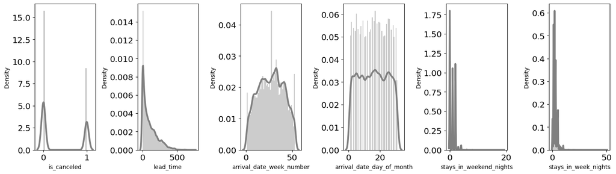

```python
plt.figure(figsize=(15,8))
for i in range(0, len(nums_a)):
    plt.subplot(2, len(nums_a), i+1)
    sns.distplot(df[nums_a[i]], color='gray')
    plt.tight_layout()
```

```python
df[nums].describe()
```

|  | is_canceled | lead_time | arrival_date_week_number | arrival_date_day_of_month | stays_in_weekend_nights | stays_in_week_nights | adults | children | babies | is_repeated_guest | previous_cancellations | previous_bookings_not_canceled | booking_changes | days_in_waiting_list | adr | required_car_parking_spaces | total_of_special_requests | total_hari |
| --- | --- | --- | --- | --- | --- | --- | --- | --- | --- | --- | --- | --- | --- | --- | --- | --- | --- | --- |
| count | 119390.000000 | 119390.000000 | 119390.000000 | 119390.000000 | 119390.000000 | 119390.000000 | 119390.000000 | 119390.000000 | 119390.000000 | 119390.000000 | 119390.000000 | 119390.000000 | 119390.000000 | 119390.000000 | 119390.000000 | 119390.000000 | 119390.000000 | 119390.000000 |
| mean | 0.370416 | 104.011416 | 27.165173 | 15.798241 | 0.927599 | 2.500302 | 1.856403 | 0.103886 | 0.007949 | 0.031912 | 0.087118 | 0.137097 | 0.221124 | 2.321149 | 101.831122 | 0.062518 | 0.571363 | 3.427900 |
| std | 0.482918 | 106.863097 | 13.605138 | 8.780829 | 0.998613 | 1.908286 | 0.579261 | 0.398555 | 0.097436 | 0.175767 | 0.844336 | 1.497437 | 0.652306 | 17.594721 | 50.535790 | 0.245291 | 0.792798 | 2.557439 |
| min | 0.000000 | 0.000000 | 1.000000 | 1.000000 | 0.000000 | 0.000000 | 0.000000 | 0.000000 | 0.000000 | 0.000000 | 0.000000 | 0.000000 | 0.000000 | 0.000000 | -6.380000 | 0.000000 | 0.000000 | 0.000000 |
| 25% | 0.000000 | 18.000000 | 16.000000 | 8.000000 | 0.000000 | 1.000000 | 2.000000 | 0.000000 | 0.000000 | 0.000000 | 0.000000 | 0.000000 | 0.000000 | 0.000000 | 69.290000 | 0.000000 | 0.000000 | 2.000000 |
| 50% | 0.000000 | 69.000000 | 28.000000 | 16.000000 | 1.000000 | 2.000000 | 2.000000 | 0.000000 | 0.000000 | 0.000000 | 0.000000 | 0.000000 | 0.000000 | 0.000000 | 94.575000 | 0.000000 | 0.000000 | 3.000000 |
| 75% | 1.000000 | 160.000000 | 38.000000 | 23.000000 | 2.000000 | 3.000000 | 2.000000 | 0.000000 | 0.000000 | 0.000000 | 0.000000 | 0.000000 | 0.000000 | 0.000000 | 126.000000 | 0.000000 | 1.000000 | 4.000000 |
| max | 1.000000 | 737.000000 | 53.000000 | 31.000000 | 19.000000 | 50.000000 | 55.000000 | 10.000000 | 10.000000 | 1.000000 | 26.000000 | 72.000000 | 21.000000 | 391.000000 | 5400.000000 | 8.000000 | 5.000000 | 69.000000 |

```python
df.sample(5)
```

|  | hotel | is_canceled | lead_time | arrival_date_year | arrival_date_month | arrival_date_week_number | arrival_date_day_of_month | stays_in_weekend_nights | stays_in_week_nights | adults | ... | adr | required_car_parking_spaces | total_of_special_requests | reservation_status | reservation_status_date | name | email | phone-number | credit_card | total_hari |
| --- | --- | --- | --- | --- | --- | --- | --- | --- | --- | --- | --- | --- | --- | --- | --- | --- | --- | --- | --- | --- | --- |
| 106493 | City Hotel | 0 | 134 | 2017 | February | 8 | 25 | 0 | 1 | 1 | ... | 75.0 | 0 | 0 | Check-Out | 2017-02-26 | Pamela Crawford | Pamela.Crawford41@xfinity.com | 948-362-7595 | ************6978 | 1 |
| 81988 | City Hotel | 1 | 115 | 2016 | March | 13 | 20 | 2 | 0 | 1 | ... | 70.0 | 0 | 0 | Canceled | 2015-12-18 | Roy Patrick | RoyPatrick54@yandex.com | 842-965-1950 | ************4589 | 2 |
| 76143 | City Hotel | 1 | 273 | 2015 | July | 29 | 17 | 0 | 2 | 2 | ... | 101.5 | 0 | 0 | Canceled | 2015-07-06 | James Luna | James.L@yahoo.com | 864-332-4006 | ************8364 | 2 |
| 92776 | City Hotel | 0 | 98 | 2016 | July | 28 | 6 | 2 | 4 | 2 | ... | 103.5 | 0 | 1 | Check-Out | 2016-07-12 | Todd Cook | Todd_Cook@yahoo.com | 353-051-0884 | ************9676 | 6 |
| 85230 | City Hotel | 0 | 8 | 2016 | March | 11 | 9 | 0 | 2 | 1 | ... | 64.4 | 0 | 0 | Check-Out | 2016-03-11 | Sandra Farrell | Farrell_Sandra41@hotmail.com | 395-991-0907 | ************8594 | 2 |

5 rows × 37 columns

## 1. Descriptive Statistics (15 poin)

### Gunakan function info dan describe pada dataset final project kalian. Tuliskan hasil

### observasinya, seperti:

- Apakah ada kolom dengan tipe data kurang sesuai, atau nama kolom dan isinya kurang sesuai?
- Apakah ada kolom yang memiliki nilai kosong? Jika ada, apa saja?
- Apakah ada kolom yang memiliki nilai summary agak aneh?(min/mean/median/max/unique/top/freq)

Untuk masing-masing jenis observasi, tuliskan juga jika tidak ada masalah, misal untuk A: “Semua tipe data sudah sesuai”

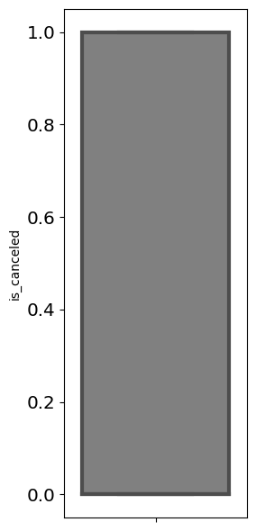

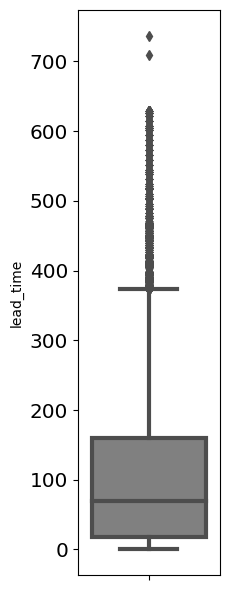

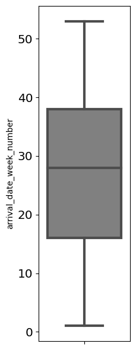

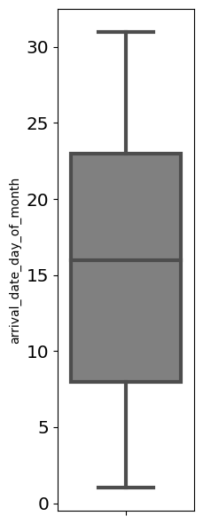

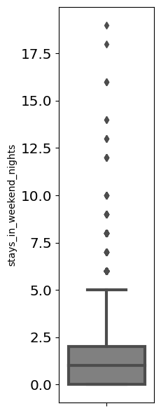

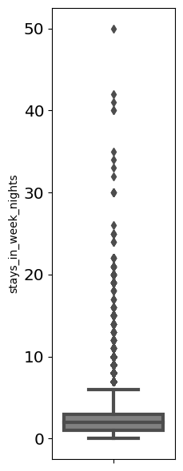

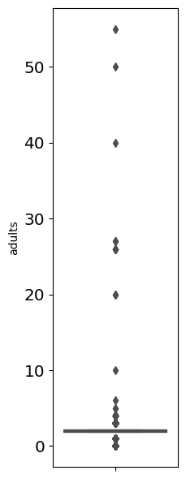

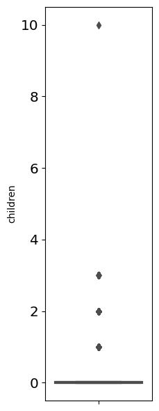

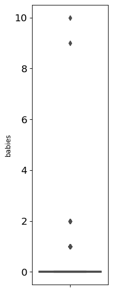

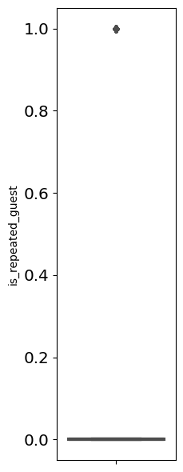

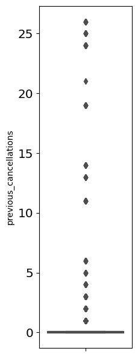

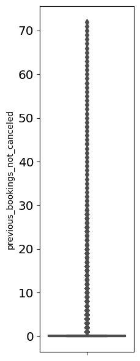

[6 more figures not shown]

```python
for i in range(0, len(nums)):
    plt.figure(figsize=(40,6))
    plt.subplot(1, len(nums), i+1)
    sns.boxplot(y=df[nums[i]], color='gray', orient='v')
    plt.tight_layout()
```

## 2. Univariate Analysis (25 poin)

Gunakan visualisasi untuk melihat distribusi masing-masing kolom (feature maupun target). Tuliskan hasil observasinya, misalnya jika ada suatu kolom yang distribusinya menarik (misal skewed, bimodal, ada outlier, ada nilai yang mendominasi, kategorinya terlalu banyak, dsb). Jelaskan juga apa yang harus di-follow up saat data pre-processing.

#### Jawaban

- skewed right distribution = lead_time, stay in week night, total hari
- bimodal = is_canceled,
- multimodal = adults, children, babies,stay in weekend night, total of special request, booking changes
- memiliki outlier = lead_time,syats_in_weekend_nights,stays_in_week_nights,adults,children,babies,previous_cancellations,previous_bookings_not_canceled,booking_changes,days_in_waiting_list kolom2 berikut memikiliki nilai outlier yang mana min,mean dan nilai max sangat jauh gapnya, dan kolom adr *perlu membuang outlier*
- normalisasi data untuk kolom arrival date week number, arrival date of month
- kolom memiliki kategory banyak = country, agent, company

```python
df[cats].describe()
```

|  | hotel | arrival_date_year | arrival_date_month | meal | country | market_segment | distribution_channel | reserved_room_type | assigned_room_type | deposit_type | agent | company | customer_type | reservation_status | phone-number | name | email | credit_card |
| --- | --- | --- | --- | --- | --- | --- | --- | --- | --- | --- | --- | --- | --- | --- | --- | --- | --- | --- |
| count | 119390 | 119390 | 119390 | 119390 | 119390 | 119390 | 119390 | 119390 | 119390 | 119390 | 119390 | 119390 | 119390 | 119390 | 119390 | 119390 | 119390 | 119390 |
| unique | 2 | 3 | 12 | 5 | 178 | 8 | 5 | 10 | 12 | 3 | 334 | 353 | 4 | 3 | 119390 | 81503 | 115889 | 9000 |
| top | City Hotel | 2016 | August | BB | PRT | Online TA | TA/TO | A | A | No Deposit | 9.0 | 0.0 | Transient | Check-Out | 669-792-1661 | Michael Johnson | Michael.C@gmail.com | ************4923 |
| freq | 79330 | 56707 | 13877 | 92310 | 48590 | 56477 | 97870 | 85994 | 74053 | 104641 | 31961 | 112593 | 89613 | 75166 | 1 | 48 | 6 | 28 |

[output not shown]

[output cut: 143 more lines]

[output not shown]

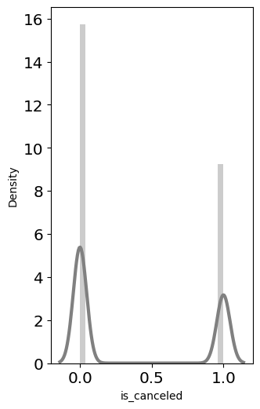

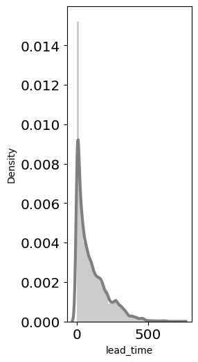

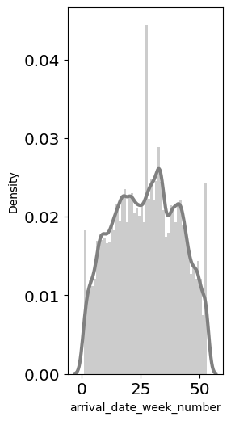

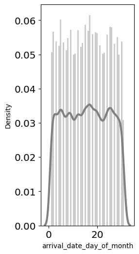

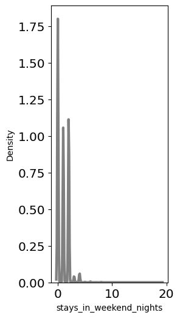

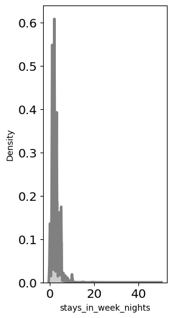

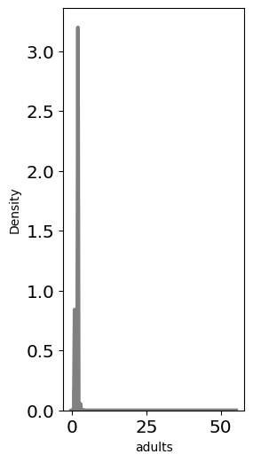

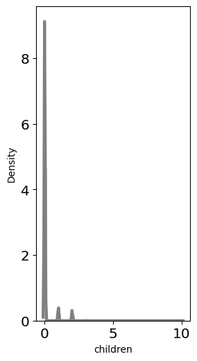

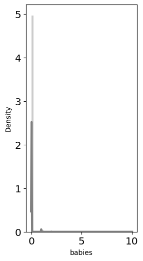

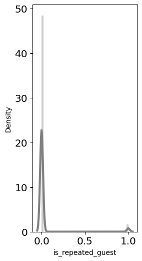

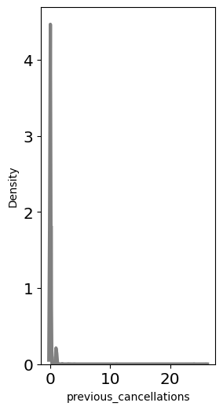

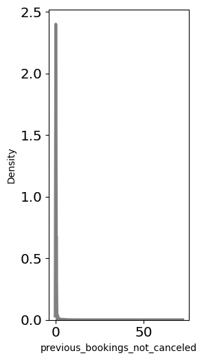

[6 more figures not shown]

```python
for i in range(0, len(nums)):
    plt.figure(figsize=(50,10))
    plt.subplot(2, len(nums), i+1)
    sns.distplot(df[nums[i]], color='gray')
    plt.tight_layout()
```

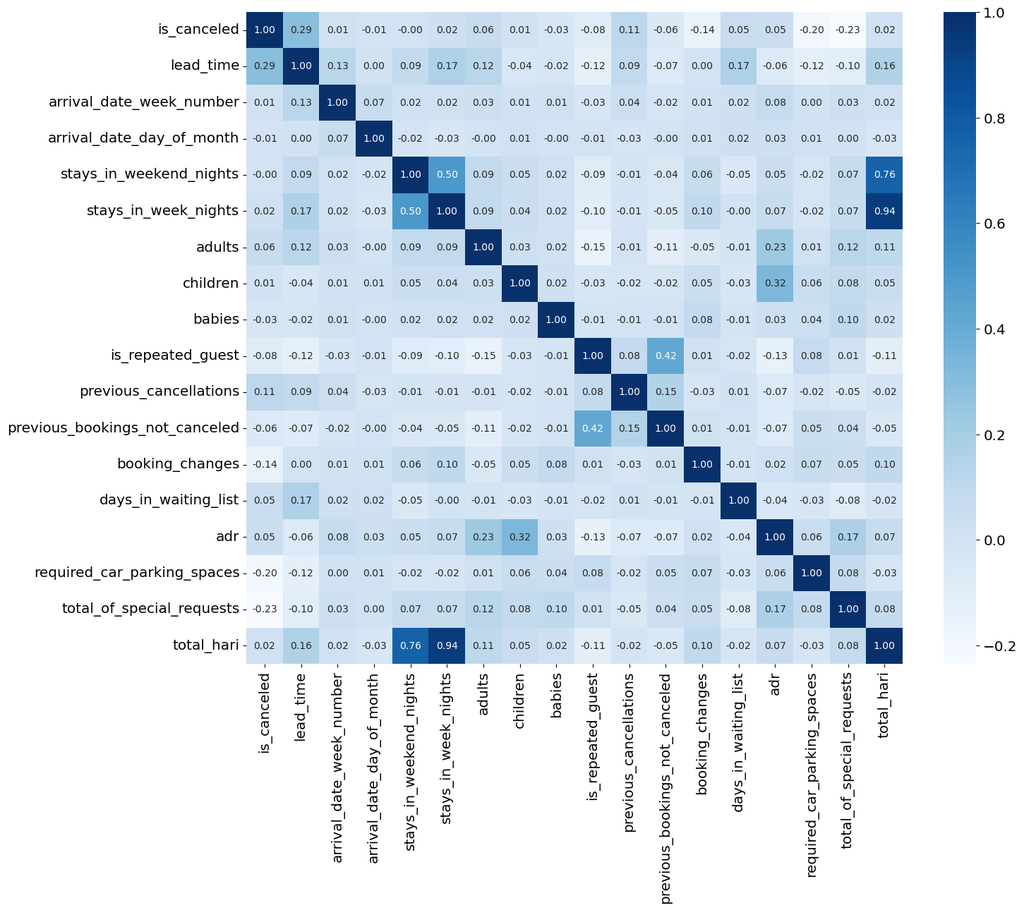

```python
plt.figure(figsize=(15, 12))
sns.heatmap(df.corr(), cmap="Blues", annot=True, fmt=".2f")
```

### 3. Multivariate Analysis (15 poin)

Lakukan multivariate analysis (seperti correlation heatmap dan category plots, sesuai yang diajarkan di kelas). Tuliskan hasil observasinya, seperti:

##### A. Bagaimana korelasi antara masing-masing feature dan label. Kira-kira feature mana saja yang paling relevan dan harus dipertahankan?

##### B. Bagaimana korelasi antar-feature, apakah ada pola yang menarik? Apa yang perlu dilakukan terhadap feature itu?

- Tuliskan juga jika memang tidak ada feature yang saling berkorelasi

### jawaban

[output not shown]

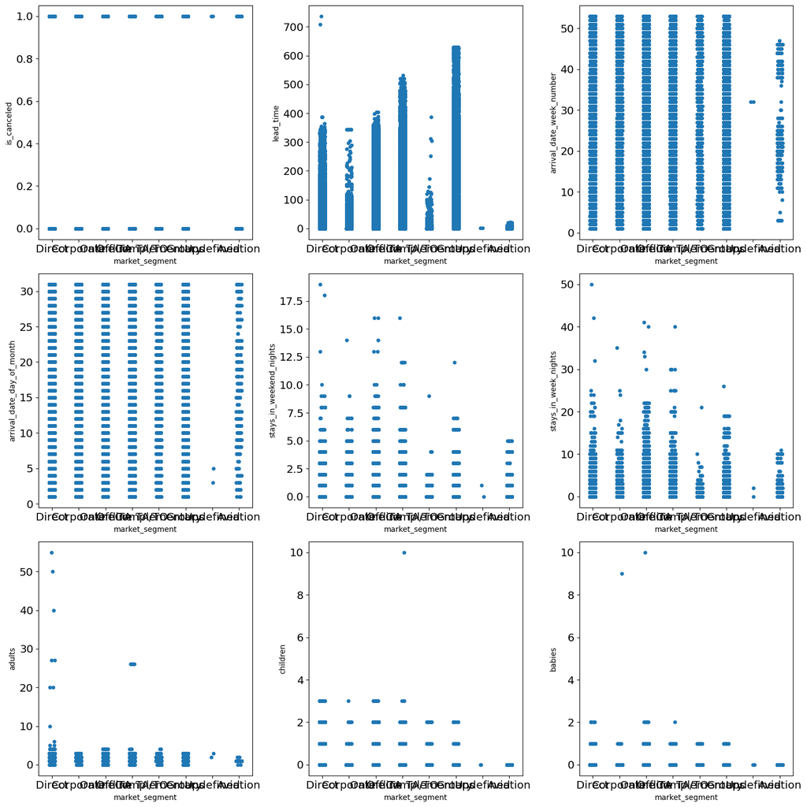

```python
fig = plt.figure(figsize=(15,15))
for i in range(0, len(cats)):
    ax=fig.add_subplot(3, 3, i+1)
    sns.stripplot(ax=ax, data=df, x='market_segment', y=nums[i])
    plt.tight_layout()
```

### 4. Business Insight (30 poin)

##### Selain EDA, lakukan juga beberapa analisis dan visualisasi untuk menemukan suatu business insight. Tuliskan minimal 3 insight, dan berdasarkan insight tersebut jelaskan rekomendasinya untuk bisnis.

### jawaban

```
 [Text(-1.0101005509609093, -0.43554204957554643, 'Not Canceled'),
 [Text(-0.5509639368877687, -0.23756839067757074, '63.0%'),
```

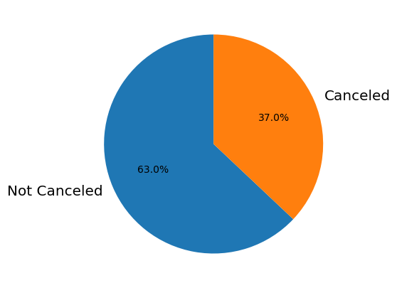

```python
num_can= df['is_canceled'].value_counts()
plt.figure(figsize=(5,5))
plt.pie(num_can, labels=['Not Canceled', 'Canceled'], autopct='%.1f%%', startangle=90)
```

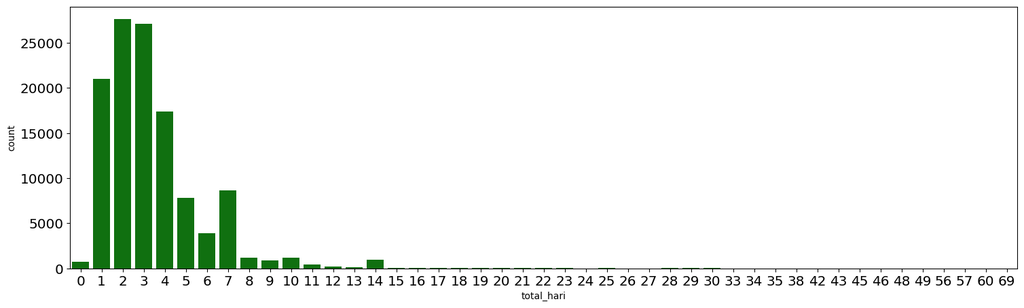

```python
plt.figure(figsize=(18,5))
sns.countplot(x=df['total_hari'], color='g')
plt.show()
```

```python
dfa = df.groupby(['market_segment', 'is_canceled']).agg({'phone-number' : 'nunique'})
dfa
```

| market_segment | is_canceled | phone-number |
| --- | --- | --- |
| Aviation | 0 | 185 |
|  | 1 | 52 |
| Complementary | 0 | 646 |
|  | 1 | 97 |
| Corporate | 0 | 4303 |
|  | 1 | 992 |
| Direct | 0 | 10672 |
|  | 1 | 1934 |
| Groups | 0 | 7714 |
|  | 1 | 12097 |
| Offline TA/TO | 0 | 15908 |
|  | 1 | 8311 |
| Online TA | 0 | 35738 |
|  | 1 | 20739 |
| Undefined | 1 | 2 |

```python
dfa1= dfa.pivot_table(index="market_segment",columns="is_canceled",values="phone-number")
dfa1.head()
```

| is_canceled market_segment | 0 | 1 |
| --- | --- | --- |
| Aviation | 185.0 | 52.0 |
| Complementary | 646.0 | 97.0 |
| Corporate | 4303.0 | 992.0 |
| Direct | 10672.0 | 1934.0 |
| Groups | 7714.0 | 12097.0 |

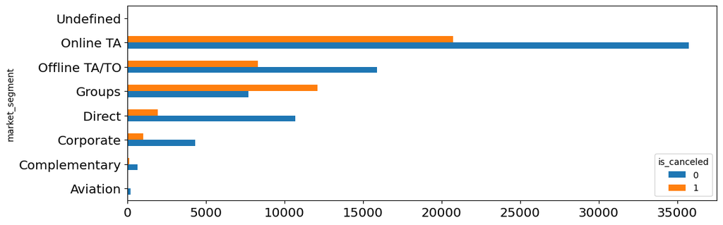

```python
dfa1.plot(kind="barh", stacked=False)
```

[output not shown]

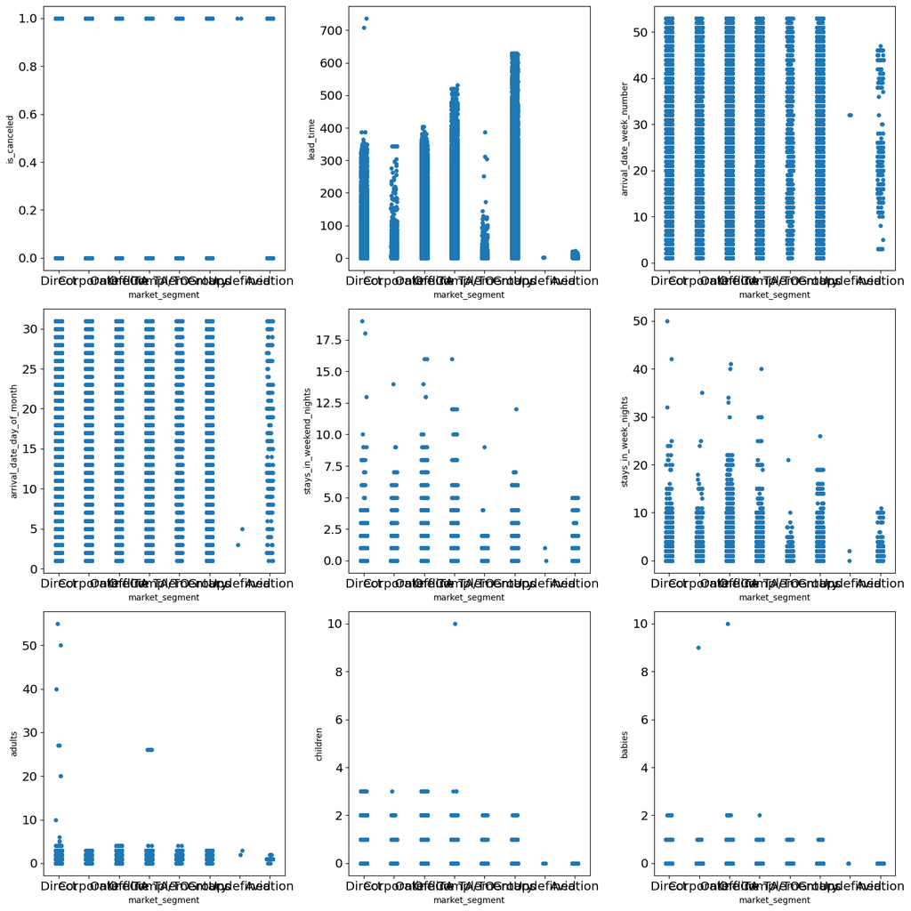

```python
fig = plt.figure(figsize=(15,15))
for i in range(0, len(cats)): #untuk setiap kolom numerik
    ax=fig.add_subplot(3, 3, i+1) #kite set posisi catplot di layout
    sns.stripplot(ax=ax, data=df, x='market_segment', y=nums[i]) #gambar catplot
    plt.tight_layout()
```